# Differential Gene Expression Analysis of Nodule-Like Structures in Oryza sativa Roots

2025-04-29

## Overview

### The Dataset

The dataset samples are wild-type Oryza sativa roots harvested for RNA. The control plants were mock incubated with water and the hormone treatment plants were incubated in 10ml of 50µM 2,4-D (synthetic auxin) for 1 hour. The RNA was extracted from control and treatment plants at 1 day and 14 days post treatment, with 3 biological replicates for each treatment group at each time point. These samples were pair-end sequenced using the Illumina HiSeq 2500 Rapid Run flow cell.

In the original paper, researchers studied DEgenes between mock and auxin treated plants to identidy genetic pathways required for nodule-like structure (NLS) development. Although they did compare gene expression across separate time points (1dpt, 7dpt, 14dpt), they did not compare within treatment groups for differential gene expression at these different time points.

I would like to look at the differences in gene expression within the auxin treatment groups across time points. In the treatment group, I would like to see if catalytic and metabolic genes are enriched at earlier time points, corresponding with the energy intensive process of symbiotic nodule development. This would help to confirm that this auxin mediated process has some genetic mechanisms homologous to nodule development in native legume plant systems.

### GEO accession number

GSE92835

### Citation

Thomas J, Hiltenbrand R, Bowman MJ, Kim HR, Winn ME, Mukherjee A. Time-course RNA-seq analysis provides an improved understanding of gene regulation during the formation of nodule-like structures in rice. Plant Mol Biol. 2020 May;103(1-2):113-128. doi: 10.1007/s11103-020-00978-0. Epub 2020 Feb 21. PMID: 32086696; PMCID: PMC7695038.

### Libraries Loaded

```r
#Downloading all required packages

#install.packages(("BiocManager"))

#BiocManager::install(c("tidyverse", "DESeq2", "ggplot2", "ggpubr", "pheatmap", "genekitr", "RColorBrewer", "clusterProfiler", "grid", "cowplot", "magick", "gridExtra", "knitr", "gprofiler2"))
```

```r
# loading all required libraries
# anything commented out would not load on my RStudio version :(

library(tidyverse)
library(DESeq2)
```

```r
library(ggplot2)
library(ggpubr)
library(pheatmap)
library(gprofiler2)
library(RColorBrewer)
library(grid)
library(cowplot)
library(gridExtra)
#library(magick)
#library(clusterProfiler)
#library(genekitr)
#library(knitr)
```

Note: I had to comment out some libraries because they would not load on my version of R. Please uncomment them out before continuing!

## Creating DESeq Objects

Files used to generate the metadata used for this analysis are the “count.txt” outputs from HTSeq analysis. These are the sorted counts from the raw RNASeq data collected during the experiment.

For this project, 2 metadata matrixes are needed: (1)Control data, (2)Treatment data

```r
# generating control sampletable
sampletable_control <- data.frame(
  samplename = c("Water_1dpt_rep1", "Water_1dpt_rep2", "Water_1dpt_rep3", "Water_14dpt_rep1", "Water_14dpt_rep2", "Water_14dpt_rep3"),
  filename = c("SRR5126147_sorted.gene_id.count.txt", "SRR5126148_sorted.gene_id.count.txt", "SRR5126149_sorted.gene_id.count.txt",  "SRR5126165_sorted.gene_id.count.txt", "SRR5126167_sorted.gene_id.count.txt", "SRR5126169_sorted.gene_id.count.txt"),
  condition = factor(c("1dpt", "1dpt", "1dpt", "14dpt", "14dpt", "14dpt")),
  replicate = factor(rep(1:3, times = 2))
)
head(sampletable_control)
```

```
##         samplename                            filename condition replicate
## 1  Water_1dpt_rep1 SRR5126147_sorted.gene_id.count.txt      1dpt         1
## 2  Water_1dpt_rep2 SRR5126148_sorted.gene_id.count.txt      1dpt         2
## 3  Water_1dpt_rep3 SRR5126149_sorted.gene_id.count.txt      1dpt         3
## 4 Water_14dpt_rep1 SRR5126165_sorted.gene_id.count.txt     14dpt         1
## 5 Water_14dpt_rep2 SRR5126167_sorted.gene_id.count.txt     14dpt         2
## 6 Water_14dpt_rep3 SRR5126169_sorted.gene_id.count.txt     14dpt         3
```

```r
# re-level to specify condition and replicate as factors
condition <- factor(sampletable_control$condition)
replicate <- factor(sampletable_control$replicate)
```

```r
# generating treatment sampletable
sampletable_treatment <- data.frame(
  samplename = c("Auxin_1dpt_rep1", "Auxin_1dpt_rep2", "Auxin_1dpt_rep3", "Auxin_14dpt_rep1", "Auxin_14dpt_rep2", "Auxin_14dpt_rep3"),
  filename = c("SRR5126150_sorted.gene_id.count.txt", "SRR5126151_sorted.gene_id.count.txt", "SRR5126152_sorted.gene_id.count.txt",  "SRR5126171_sorted.gene_id.count.txt", "SRR5126173_sorted.gene_id.count.txt", "SRR5126175_sorted.gene_id.count.txt"),
  condition = factor(c("1dpt", "1dpt", "1dpt", "14dpt", "14dpt", "14dpt")),
  replicate = factor(rep(1:3, times = 2))
)
head(sampletable_treatment)
```

```
##         samplename                            filename condition replicate
## 1  Auxin_1dpt_rep1 SRR5126150_sorted.gene_id.count.txt      1dpt         1
## 2  Auxin_1dpt_rep2 SRR5126151_sorted.gene_id.count.txt      1dpt         2
## 3  Auxin_1dpt_rep3 SRR5126152_sorted.gene_id.count.txt      1dpt         3
## 4 Auxin_14dpt_rep1 SRR5126171_sorted.gene_id.count.txt     14dpt         1
## 5 Auxin_14dpt_rep2 SRR5126173_sorted.gene_id.count.txt     14dpt         2
## 6 Auxin_14dpt_rep3 SRR5126175_sorted.gene_id.count.txt     14dpt         3
```

```r
# re-level to specify condition and replicate as factors
condition <- factor(sampletable_control$condition)
replicate <- factor(sampletable_control$replicate)
```

## Creating DESeq Dataset

```r
# creating control DESeqDataSet
dds_control <- DESeqDataSetFromHTSeqCount(
  sampleTable = sampletable_control,
  directory = "HT-Seq-txt/",
  design = ~ replicate + condition
)

dds_control
```

```
## class: DESeqDataSet
## dim: 38993 6
## metadata(1): version
## assays(1): counts
## rownames(38993): ENSRNA049440515 ENSRNA049440716 ... gene-rps7-3
##   gene-rps8
## rowData names(0):
## colnames(6): Water_1dpt_rep1 Water_1dpt_rep2 ... Water_14dpt_rep2
##   Water_14dpt_rep3
## colData names(2): condition replicate
```

```r
# creating treatment DESeqDataSet
dds_treatment <- DESeqDataSetFromHTSeqCount(
  sampleTable = sampletable_treatment,
  directory = "HT-Seq-txt/",
  design = ~ replicate + condition
)

dds_treatment
```

```
## class: DESeqDataSet
## dim: 38993 6
## metadata(1): version
## assays(1): counts
## rownames(38993): ENSRNA049440515 ENSRNA049440716 ... gene-rps7-3
##   gene-rps8
## rowData names(0):
## colnames(6): Auxin_1dpt_rep1 Auxin_1dpt_rep2 ... Auxin_14dpt_rep2
##   Auxin_14dpt_rep3
## colData names(2): condition replicate
```

## Prefiltering Data

```r
#Pre-filtering (Getting rid of rows that have less than 10 reads) for both control and treatment dds objects
keep_control <- rowSums(counts(dds_control)) >= 10
dds_control <- dds_control[keep_control,]

keep_treatment <- rowSums(counts(dds_treatment)) >= 10
dds_treatment <- dds_treatment[keep_treatment,]
```

## Relevling Data

```r
#releveling to specify reference level as "1dpt" for both control and treatment dds objects
dds_control$condition <- relevel(dds_control$condition, ref = "1dpt")
dds_treatment$condition <- relevel(dds_treatment$condition, ref = "1dpt")
```

## Normalization and Checking Data Patterning

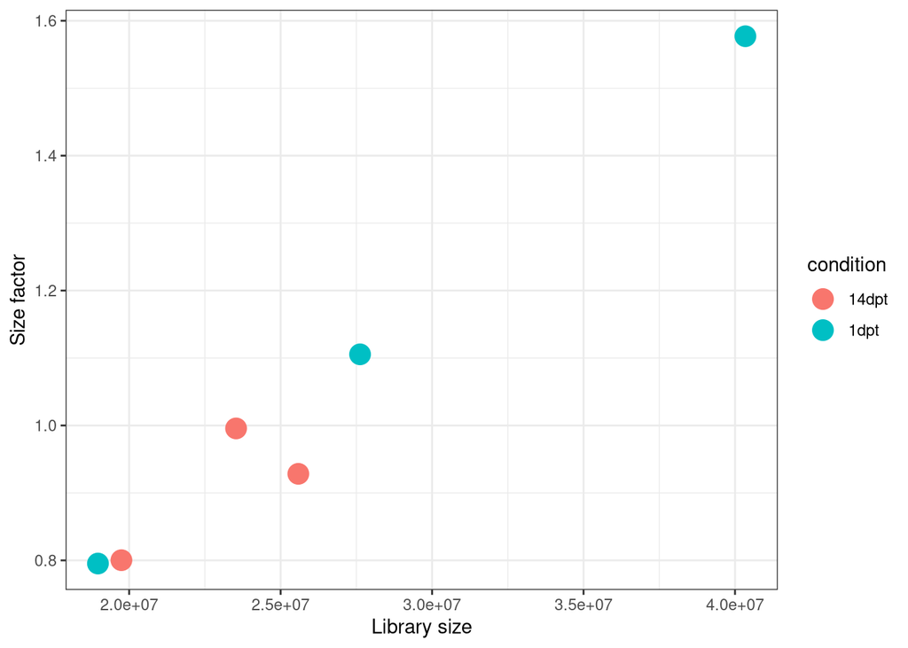

```r
# normalizing control raw counts data
dds_control <- estimateSizeFactors(dds_control)

# plot the control size factors against library size and look for any patterns by group:

ggplot(data.frame(libSize = colSums(assay(dds_control)),
                  sizeFactor = sizeFactors(dds_control),
                  Group = dds_control$condition),
       aes(x = libSize, y = sizeFactor, col = condition)) +
  geom_point(size = 5) + theme_bw() +
  labs(x = "Library size", y = "Size factor")
```

There is not much clustering for these samples based on timepoint. However, these are just samples from untreated growing plants so I did not expect much clustering based on timepoint for this dataset.

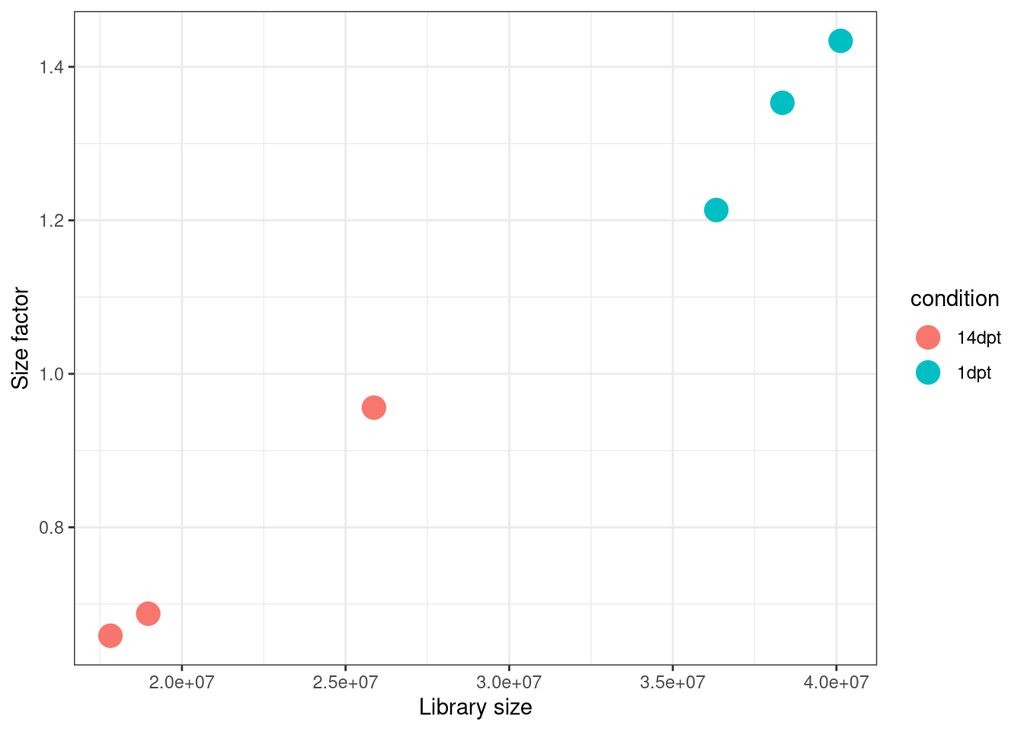

```r
# normalizing treatment raw counts data
dds_treatment <- estimateSizeFactors(dds_treatment)

# Plot the treatment size factors against library size and look for any patterns by group:

ggplot(data.frame(libSize = colSums(assay(dds_treatment)),
                  sizeFactor = sizeFactors(dds_treatment),
                  Group = dds_treatment$condition),
       aes(x = libSize, y = sizeFactor, col = condition)) +
  geom_point(size = 5) + theme_bw() +
  labs(x = "Library size", y = "Size factor")
```

Clustering of samples based on library size and size factor shows that normalized data is similar based on biological factors rather than confounding/corrupt counts data.

## Differential Expression Analysis (DESEq)

Here I want to generate lists of differentially expressed genes for the control and treatment datasets. I would like to see what genes are upregulated at 1dpt and downregulated at 14dpt. Downstream, I would like to analyze the GOterms for these genes and see if they are important for auxin response, catalytic activity, and metabolic activity.

In order to do so, I need to organize my data into tables, sort these tables based on significance, and filter my tables to make my datasets easier to manipulate with visualization packages.

```r
# generate control results table
dds_control <- DESeq(dds_control)
res_control <- results(dds_control, contrast= c('condition', '1dpt', '14dpt'))

head(res_control)
```

```
## log2 fold change (MLE): condition 1dpt vs 14dpt
## Wald test p-value: condition 1dpt vs 14dpt
## DataFrame with 6 rows and 6 columns
##                  baseMean log2FoldChange     lfcSE       stat    pvalue
##                 <numeric>      <numeric> <numeric>  <numeric> <numeric>
## ENSRNA049448805   4.09132       0.156337  2.156238  0.0725046  0.942200
## ENSRNA049464427   4.78657       4.479670  2.252066  1.9891378  0.046686
## ENSRNA049464972 110.96259       0.339889  0.503852  0.6745804  0.499942
## ENSRNA049465030  10.61600      -1.464132  1.162224 -1.2597671  0.207753
## ENSRNA049465332  11.44138       1.199638  1.117883  1.0731340  0.283211
## ENSRNA049465347  11.17871       0.420052  1.071753  0.3919294  0.695110
##                      padj
##                 <numeric>
## ENSRNA049448805        NA
## ENSRNA049464427        NA
## ENSRNA049464972  0.999974
## ENSRNA049465030  0.999974
## ENSRNA049465332  0.999974
## ENSRNA049465347  0.999974
```

```r
# cleaning data to only contain ENSIds
res_control_clean <- res_control[grepl("^Os", rownames(res_control)), ]

head(rownames(res_control_clean))
```

```
## [1] "Os01g0100100" "Os01g0100200" "Os01g0100300" "Os01g0100400" "Os01g0100500"
## [6] "Os01g0100600"
```

```r
nrow(res_control_clean)
```

```
## [1] 30106
```

```r
# order control results table by the smallest *padj* value
result_control <- res_control_clean[order(res_control_clean$padj), ]

head(result_control)
```

```
## log2 fold change (MLE): condition 1dpt vs 14dpt
## Wald test p-value: condition 1dpt vs 14dpt
## DataFrame with 6 rows and 6 columns
##               baseMean log2FoldChange     lfcSE      stat      pvalue
##              <numeric>      <numeric> <numeric> <numeric>   <numeric>
## Os01g0764050  966.3382       -3.88870  0.386922 -10.05035 9.15440e-24
## Os09g0522200 1501.5202       -4.11384  0.417677  -9.84932 6.90076e-23
## Os12g0132500  111.7372       -7.22338  0.979812  -7.37221 1.67822e-13
## Os05g0135750  531.0280       -4.39333  0.599606  -7.32704 2.35293e-13
## Os11g0134950   82.4967       -6.75192  0.929690  -7.26255 3.79858e-13
## Os07g0147500  206.4195       -3.87150  0.551710  -7.01728 2.26224e-12
##                     padj
##                <numeric>
## Os01g0764050 2.50281e-19
## Os09g0522200 9.43334e-19
## Os12g0132500 1.52941e-09
## Os05g0135750 1.60823e-09
## Os11g0134950 2.07706e-09
## Os07g0147500 1.03083e-08
```

```r
# identify number of DEG based on padj < 0.05 for control
table(result_control$padj<0.05)
```

```
##
## FALSE  TRUE
## 26958   291
```

```r
#Merging stats and counts files for control data into 1 object for control
resdata_control <- merge(as.data.frame(result_control),
                 as.data.frame(counts(dds_control, normalized=TRUE)),
                 by="row.names",
                 sort=FALSE)

names(resdata_control)[1] <- "Gene_id"

head(resdata_control)
```

```
##        Gene_id   baseMean log2FoldChange     lfcSE       stat       pvalue
## 1 Os01g0764050  966.33821      -3.888703 0.3869223 -10.050347 9.154405e-24
## 2 Os09g0522200 1501.52024      -4.113838 0.4176773  -9.849322 6.900758e-23
## 3 Os12g0132500  111.73725      -7.223383 0.9798123  -7.372211 1.678217e-13
## 4 Os05g0135750  531.02796      -4.393335 0.5996057  -7.327039 2.352933e-13
## 5 Os11g0134950   82.49672      -6.751922 0.9296902  -7.262551 3.798580e-13
## 6 Os07g0147500  206.41952      -3.871503 0.5517097  -7.017283 2.262236e-12
##           padj Water_1dpt_rep1 Water_1dpt_rep2 Water_1dpt_rep3 Water_14dpt_rep1
## 1 2.502814e-19      134.425547        108.1364      123.026508        1557.0112
## 2 9.433336e-19       10.145324        461.4659       19.901347         226.1790
## 3 1.529415e-09        4.438579          0.0000        0.000000         593.5636
## 4 1.608230e-09       24.095145        144.6010       28.042807         672.2889
## 5 2.077064e-09        2.536331          0.0000        1.809213         228.6782
## 6 1.030826e-08       35.508635         12.5740       36.184267         401.1241
##   Water_14dpt_rep2 Water_14dpt_rep3
## 1        1877.6561       1997.77352
## 2        8021.2433        270.18657
## 3          31.2404         41.18085
## 4        1158.0495       1159.09032
## 5         160.5110        101.44551
## 6         383.5029        369.62326
```

```r
#saving unfiltered results for control
write.csv(resdata_control,
          file = "control_1dptvs14dpt_matrix.csv",
          row.names = FALSE)
```

```r
# generate treatment results table
dds_treatment <- DESeq(dds_treatment)
res_treatment <- results(dds_treatment, contrast= c('condition', '1dpt', '14dpt'))

head(res_treatment)
```

```
## log2 fold change (MLE): condition 1dpt vs 14dpt
## Wald test p-value: condition 1dpt vs 14dpt
## DataFrame with 6 rows and 6 columns
##                  baseMean log2FoldChange     lfcSE        stat     pvalue
##                 <numeric>      <numeric> <numeric>   <numeric>  <numeric>
## ENSRNA049445225   3.22778     0.77157637  2.082335  0.37053421 0.71098449
## ENSRNA049448805   2.48060    -2.37559148  2.479627 -0.95804404 0.33804055
## ENSRNA049450733   1.55599    -0.00813618  2.565698 -0.00317114 0.99746980
## ENSRNA049464427  12.33536    -4.74714384  1.447025 -3.28062212 0.00103578
## ENSRNA049464535   2.51786     0.02436140  2.261065  0.01077430 0.99140352
## ENSRNA049464972 122.25749     0.08569590  0.408215  0.20992844 0.83372352
##                       padj
##                  <numeric>
## ENSRNA049445225 0.83454697
## ENSRNA049448805         NA
## ENSRNA049450733         NA
## ENSRNA049464427 0.00703204
## ENSRNA049464535         NA
## ENSRNA049464972 0.91081574
```

```r
# cleaning data to only contain ENSIds
res_treatment_clean <- res_treatment[grepl("^Os", rownames(res_treatment)), ]

head(rownames(res_treatment_clean))
```

```
## [1] "Os01g0100100" "Os01g0100200" "Os01g0100400" "Os01g0100500" "Os01g0100600"
## [6] "Os01g0100650"
```

```r
nrow(res_treatment_clean)
```

```
## [1] 29767
```

```r
# order treatment results table by the smallest *padj* value
result_treatment <- res_treatment_clean[order(res_treatment_clean$padj), ]

head(result_treatment)
```

```
## log2 fold change (MLE): condition 1dpt vs 14dpt
## Wald test p-value: condition 1dpt vs 14dpt
## DataFrame with 6 rows and 6 columns
##               baseMean log2FoldChange     lfcSE      stat      pvalue
##              <numeric>      <numeric> <numeric> <numeric>   <numeric>
## Os02g0585700  1201.993       -7.26297  0.469427  -15.4720 5.36337e-54
## Os09g0522200  2206.043       -5.84116  0.381891  -15.2954 8.21163e-53
## Os12g0225150   356.552       -5.50340  0.374848  -14.6817 8.44901e-49
## Os03g0158550   431.160       -7.10803  0.493233  -14.4111 4.40628e-47
## Os09g0522000   738.337       -6.65696  0.477607  -13.9382 3.71418e-44
## Os02g0568700   690.916        6.05520  0.437061   13.8544 1.19734e-43
##                     padj
##                <numeric>
## Os02g0585700 1.54352e-49
## Os09g0522200 1.18161e-48
## Os12g0225150 8.10514e-45
## Os03g0158550 3.17021e-43
## Os09g0522000 2.13781e-40
## Os02g0568700 5.74306e-40
```

```r
# identify number of DEG based on padj < 0.05 for control
table(result_treatment$padj<0.05)
```

```
##
## FALSE  TRUE
## 21389  7235
```

```r
#Merging stats and counts files for control data into 1 object for control
resdata_treatment <- merge(as.data.frame(result_treatment),
                 as.data.frame(counts(dds_treatment, normalized=TRUE)),
                 by="row.names",
                 sort=FALSE)

names(resdata_treatment)[1] <- "Gene_id"

head(resdata_treatment)
```

```
##        Gene_id  baseMean log2FoldChange     lfcSE      stat       pvalue
## 1 Os02g0585700 1201.9925      -7.262966 0.4694271 -15.47198 5.363368e-54
## 2 Os09g0522200 2206.0426      -5.841158 0.3818911 -15.29535 8.211632e-53
## 3 Os12g0225150  356.5519      -5.503397 0.3748483 -14.68166 8.449012e-49
## 4 Os03g0158550  431.1597      -7.108026 0.4932327 -14.41110 4.406283e-47
## 5 Os09g0522000  738.3371      -6.656960 0.4776070 -13.93815 3.714185e-44
## 6 Os02g0568700  690.9160       6.055200 0.4370613  13.85435 1.197344e-43
##           padj Auxin_1dpt_rep1 Auxin_1dpt_rep2 Auxin_1dpt_rep3 Auxin_14dpt_rep1
## 1 1.543524e-49        9.764108       25.126274       9.0652147       1024.67230
## 2 1.181613e-48       40.451303      150.757643      17.3063190       4009.12526
## 3 8.105137e-45       18.133343       16.258177      11.5375460        839.47227
## 4 3.170211e-43        6.276926        7.390081       4.1205521       1167.36741
## 5 2.137810e-40       19.528215       18.475201       0.8241104       1481.60025
## 6 5.743062e-40      675.815733      572.731240    2846.4774186         12.14426
##   Auxin_14dpt_rep2 Auxin_14dpt_rep3
## 1       2319.16470       3824.16266
## 2       8484.77440        533.84089
## 3        558.60801        695.30230
## 4        518.85687        882.94665
## 5       2881.95703         27.63754
## 6         13.59907         24.72832
```

```r
#saving unfiltered results for treatment
write.csv(resdata_treatment,
          file = "treatment_1dptvs14dpt_matrix.csv",
          row.names = FALSE)
```

The code below is used to generate a list of of differentially expressed genes (DEGs) based using a log2FoldChange of 1 and a padj < 0.05.

```r
# DEG up/down lists for control groups
resdata_control_filtered <- as.data.frame(resdata_control) |>
  dplyr::filter(abs(log2FoldChange) > 1 & padj < 0.05)

# write results
write.csv(resdata_control_filtered,
          "Control1dptvs14dpt_log2fc1_fdr05_DEGlist.csv",
          row.names = FALSE)

nrow(resdata_control_filtered)
```

```
## [1] 291
```

```r
resdata_control$diffexpressed <- "Unchanged"

#if log2FC > 1 and padj < 0.05 set as upregulated
resdata_control$diffexpressed[resdata_control$padj < 0.05 & resdata_control$log2FoldChange > 1] <- "Upregulated"

#if log2FC > -1 and padj < 0.05 set as downregulated
resdata_control$diffexpressed[resdata_control$padj < 0.05 & resdata_control$log2FoldChange < -1] <- "Downregulated"

str(resdata_control)
```

```
## 'data.frame':    30106 obs. of  14 variables:
##  $ Gene_id         : 'AsIs' chr  "Os01g0764050" "Os09g0522200" "Os12g0132500" "Os05g0135750" ...
##  $ baseMean        : num  966.3 1501.5 111.7 531 82.5 ...
##  $ log2FoldChange  : num  -3.89 -4.11 -7.22 -4.39 -6.75 ...
##  $ lfcSE           : num  0.387 0.418 0.98 0.6 0.93 ...
##  $ stat            : num  -10.05 -9.85 -7.37 -7.33 -7.26 ...
##  $ pvalue          : num  9.15e-24 6.90e-23 1.68e-13 2.35e-13 3.80e-13 ...
##  $ padj            : num  2.50e-19 9.43e-19 1.53e-09 1.61e-09 2.08e-09 ...
##  $ Water_1dpt_rep1 : num  134.43 10.15 4.44 24.1 2.54 ...
##  $ Water_1dpt_rep2 : num  108 461 0 145 0 ...
##  $ Water_1dpt_rep3 : num  123.03 19.9 0 28.04 1.81 ...
##  $ Water_14dpt_rep1: num  1557 226 594 672 229 ...
##  $ Water_14dpt_rep2: num  1877.7 8021.2 31.2 1158 160.5 ...
##  $ Water_14dpt_rep3: num  1997.8 270.2 41.2 1159.1 101.4 ...
##  $ diffexpressed   : chr  "Downregulated" "Downregulated" "Downregulated" "Downregulated" ...
```

Number of Upregulated and Downregulated genes for control dataset

```r
# number of "Upregulated" genes
sum(grepl("Upregulated", resdata_control$diffexpressed))
```

```
## [1] 15
```

```r
# number of "Downregulated" genes
sum(grepl("Downregulated", resdata_control$diffexpressed))
```

```
## [1] 276
```

```r
#Get DEG up/down lists for treatment groups
resdata_treatment_filtered <- as.data.frame(resdata_treatment) |>
  dplyr::filter(abs(log2FoldChange) > 1 & padj < 0.05)

#write results
write.csv(resdata_treatment_filtered,
          "Treatment1dptvs14dpt_log2fc1_fdr05_DEGlist.csv",
          row.names = FALSE)

#determining the number of differentially expressed genes
nrow(resdata_treatment_filtered)
```

```
## [1] 5754
```

```r
resdata_treatment$diffexpressed <- "Unchanged"

#if log2FC > 1 and padj < 0.05 set as upregulated
resdata_treatment$diffexpressed[resdata_treatment$padj < 0.05 & resdata_treatment$log2FoldChange > 1] <- "Upregulated"

#if log2FC > -1 and padj < 0.05 set as downregulated
resdata_treatment$diffexpressed[resdata_treatment$padj < 0.05 & resdata_treatment$log2FoldChange < -1] <- "Downregulated"

str(resdata_treatment)
```

```
## 'data.frame':    29767 obs. of  14 variables:
##  $ Gene_id         : 'AsIs' chr  "Os02g0585700" "Os09g0522200" "Os12g0225150" "Os03g0158550" ...
##  $ baseMean        : num  1202 2206 357 431 738 ...
##  $ log2FoldChange  : num  -7.26 -5.84 -5.5 -7.11 -6.66 ...
##  $ lfcSE           : num  0.469 0.382 0.375 0.493 0.478 ...
##  $ stat            : num  -15.5 -15.3 -14.7 -14.4 -13.9 ...
##  $ pvalue          : num  5.36e-54 8.21e-53 8.45e-49 4.41e-47 3.71e-44 ...
##  $ padj            : num  1.54e-49 1.18e-48 8.11e-45 3.17e-43 2.14e-40 ...
##  $ Auxin_1dpt_rep1 : num  9.76 40.45 18.13 6.28 19.53 ...
##  $ Auxin_1dpt_rep2 : num  25.13 150.76 16.26 7.39 18.48 ...
##  $ Auxin_1dpt_rep3 : num  9.065 17.306 11.538 4.121 0.824 ...
##  $ Auxin_14dpt_rep1: num  1025 4009 839 1167 1482 ...
##  $ Auxin_14dpt_rep2: num  2319 8485 559 519 2882 ...
##  $ Auxin_14dpt_rep3: num  3824.2 533.8 695.3 882.9 27.6 ...
##  $ diffexpressed   : chr  "Downregulated" "Downregulated" "Downregulated" "Downregulated" ...
```

Number of Upregulated and Downregulated genes for treatment dataset

```r
# number of "Upregulated" genes
sum(grepl("Upregulated", resdata_treatment$diffexpressed))
```

```
## [1] 2578
```

```r
# number of "Downregulated" genes
sum(grepl("Downregulated", resdata_treatment$diffexpressed))
```

```
## [1] 3176
```

# Data Quality Visualizations

## PCA Component Analysis (PCA)

PCA plots are an important visualization of variance in your samples. We should see clustering of data based on the time timepoints in the experiment (1dpt and 14dpt) for both the control and treatment datasets. Clustering helps to elucidate that the differences between the samples are representative of the variables we are trying to test.

```r
# stabilize variance
vstcounts_control <- vst(dds_control, blind = FALSE)
vst_mat_control <- assay(vstcounts_control)

pcaData_control <- plotPCA(vstcounts_control, intgroup = "condition", returnData = TRUE)
```

```
## using ntop=500 top features by variance
```

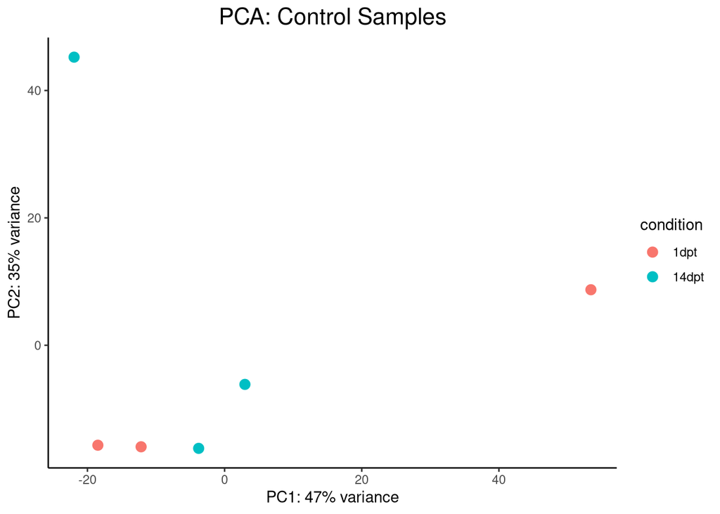

```r
percentVar <- round(100 * attr(pcaData_control, "percentVar"))

# use ggplot to create PCA: Control Samples
pca_control <- ggplot(pcaData_control, aes(PC1, PC2, color = condition)) +
  geom_point(size = 3) +
  ggtitle("PCA: Control Samples") +
  xlab(paste0("PC1: ", percentVar[1], "% variance")) +
  ylab(paste0("PC2: ", percentVar[2], "% variance")) +
  theme_classic() +
  theme(plot.title = element_text(hjust = 0.5, size = 16))

print(pca_control)
```

```r
# stabilize variance
vstcounts_treatment <- vst(dds_treatment, blind = FALSE)
vst_mat_treatment <- assay(vstcounts_treatment)

pcaData_treatment <- plotPCA(vstcounts_treatment, intgroup = "condition", returnData = TRUE)
```

```
## using ntop=500 top features by variance
```

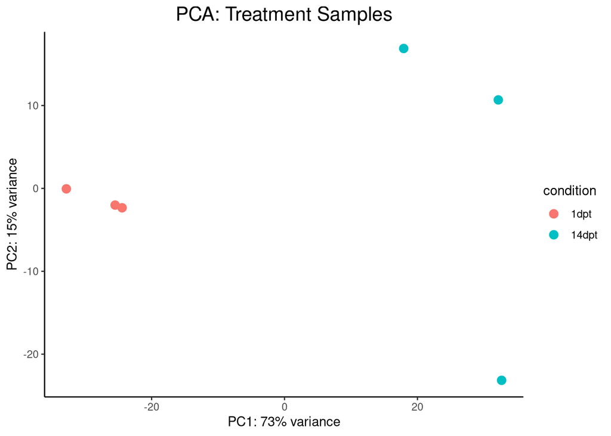

```r
percentVar <- round(100 * attr(pcaData_treatment, "percentVar"))

# use ggplot to create PCA: Treatment Samples
pca_treatment <- ggplot(pcaData_treatment, aes(PC1, PC2, color = condition)) +
  geom_point(size = 3) +
  ggtitle("PCA: Treatment Samples") +
  xlab(paste0("PC1: ", percentVar[1], "% variance")) +
  ylab(paste0("PC2: ", percentVar[2], "% variance")) +
  theme_classic() +
  theme(plot.title = element_text(hjust = 0.5, size = 16))

print(pca_treatment)
```

## Correlation Heatmaps

The correlation heatmap represents the relationship between the timepoints in a schematic matrix.

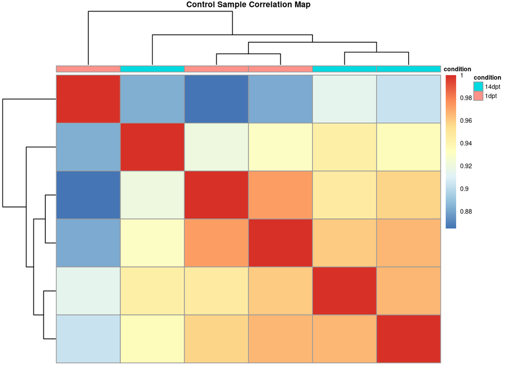

```r
# creating annotation data frame
vst_cor_control <- cor(vst_mat_control)
annotation_heatmap <- data.frame(row.names=colnames(vst_mat_control), condition)

# use pheatmap to create Control Sample Correlation Map
pheatmap(vst_cor_control,
         annotation_col = annotation_heatmap,
         main = "Control Sample Correlation Map",
         show_rownames = F,
         show_colnames = F,
         fontsize = 6,  # Decrease  font size
         fontsize_col = 6,
         fontsize_row = 6,
         width = 3,
         height = 4)# Decrease legend size
```

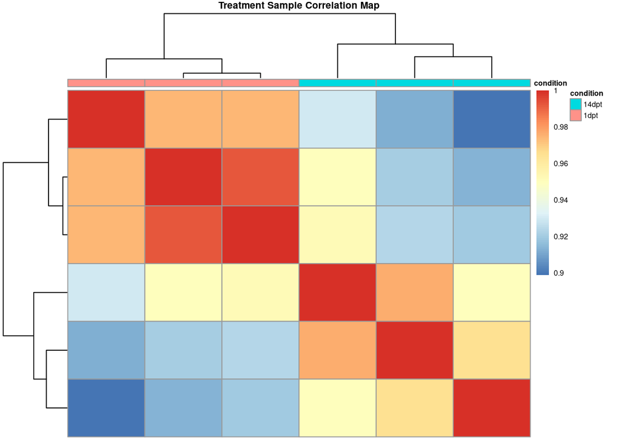

```r
# creating annotation data frame
vst_cor_treatment <- cor(vst_mat_treatment)
annotation_heatmap <- data.frame(row.names=colnames(vst_mat_treatment), condition)

# use pheatmap to create Treatment Sample Correlation Map
pheatmap(vst_cor_treatment,
         annotation_col = annotation_heatmap,
         main = "Treatment Sample Correlation Map",
         show_rownames = F,
         show_colnames = F,
         fontsize = 6,  # Decrease  font size
         fontsize_col = 6,
         fontsize_row = 6,
         width = 3,
         height = 4)# Decrease legend size
```

## Volcano Plots

The volcano plots will highlight the changes in gene expression throughout the experiment for the control and treatment dataset. Each volcano plot is representing the DEGs at 1dpt vs 14dpt.

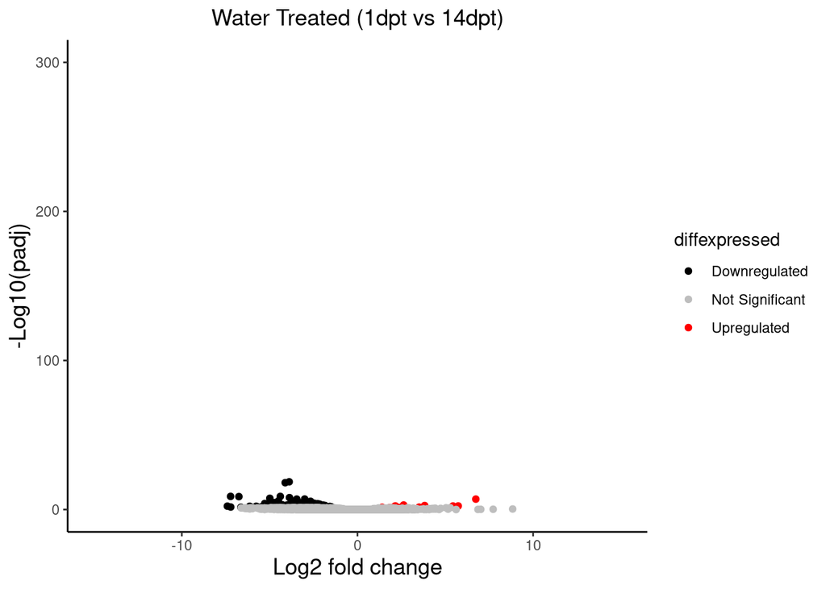

```r
# creating volcano plot for control data
volcanoplot_control <- ggplot(resdata_control) +
  geom_point(aes(x=log2FoldChange,
                 y=-log10(padj),
                 color=diffexpressed)) +
  theme_classic() +
        ggtitle("Water Treated (1dpt vs 14dpt)") +
        xlab("Log2 fold change") +
        ylab("-Log10(padj)") +
        theme(legend.position = "right",
              plot.title = element_text(size = rel(1.25), hjust = 0.5),
              axis.title = element_text(size = rel(1.25))) +
  scale_color_manual(values = c("black", "grey", "red"),
                     labels = c("Downregulated", "Not Significant", "Upregulated")) +
  scale_x_continuous(limits = c(-15, 15)) +
  coord_cartesian(ylim=c(0, 300), clip = "off")

print(volcanoplot_control)
```

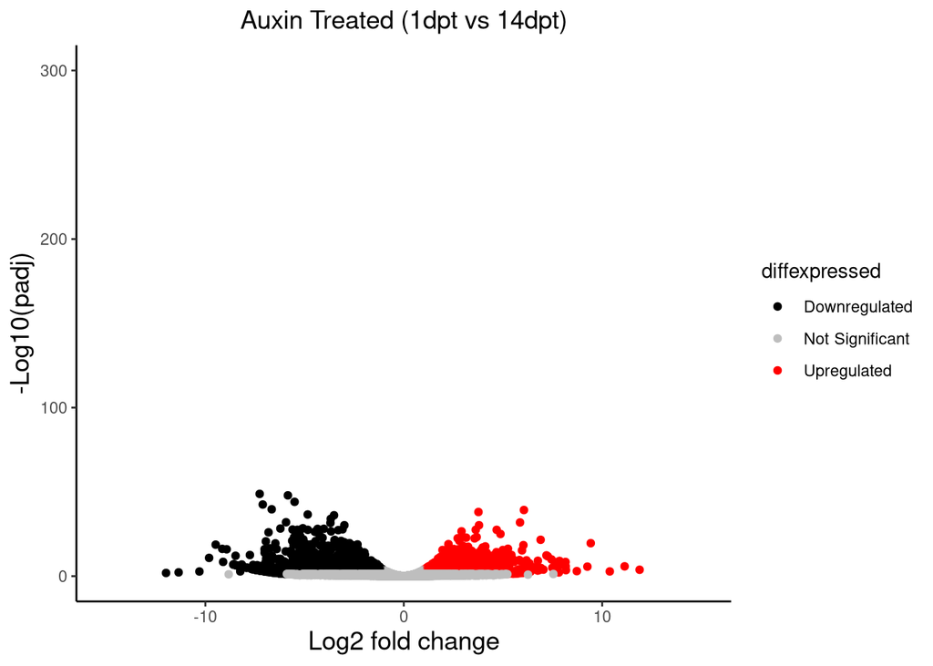

```r
# creating volcano plot for treatment data
volcanoplot_treatment <- ggplot(resdata_treatment) +
  geom_point(aes(x=log2FoldChange,
                 y=-log10(padj),
                 color=diffexpressed)) +
  theme_classic() +
        ggtitle("Auxin Treated (1dpt vs 14dpt)") +
        xlab("Log2 fold change") +
        ylab("-Log10(padj)") +
        theme(legend.position = "right",
              plot.title = element_text(size = rel(1.25), hjust = 0.5),
              axis.title = element_text(size = rel(1.25))) +
  scale_color_manual(values = c("black", "grey", "red"),
                     labels = c("Downregulated", "Not Significant", "Upregulated")) +
  scale_x_continuous(limits = c(-15, 15)) +
  coord_cartesian(ylim=c(0, 300), clip = "off")

print(volcanoplot_treatment)
```

## Heatmaps

Heatmaps here will highlight the changes throughout the course of the experiment for the control and treatment plants. This will help identify patterns of gene expression and will highlight differentially expressed genes of interest, specifically for the treatment dataset.

### Organizingg Data for Heatmap Generation

```r
#Selecting columns of interest for heatmap (control)
heatmap_matrix_control <- select(resdata_control_filtered,
                                 Gene_id,
                                 Water_1dpt_rep1:Water_14dpt_rep3)

heatmap_matrix_control <- data.frame(heatmap_matrix_control, row.names = 1)

head(heatmap_matrix_control)
```

```
##              Water_1dpt_rep1 Water_1dpt_rep2 Water_1dpt_rep3 Water_14dpt_rep1
## Os01g0764050      134.425547        108.1364      123.026508        1557.0112
## Os09g0522200       10.145324        461.4659       19.901347         226.1790
## Os12g0132500        4.438579          0.0000        0.000000         593.5636
## Os05g0135750       24.095145        144.6010       28.042807         672.2889
## Os11g0134950        2.536331          0.0000        1.809213         228.6782
## Os07g0147500       35.508635         12.5740       36.184267         401.1241
##              Water_14dpt_rep2 Water_14dpt_rep3
## Os01g0764050        1877.6561       1997.77352
## Os09g0522200        8021.2433        270.18657
## Os12g0132500          31.2404         41.18085
## Os05g0135750        1158.0495       1159.09032
## Os11g0134950         160.5110        101.44551
## Os07g0147500         383.5029        369.62326
```

```r
#Selecting columns of interest for heatmap (treatment)
heatmap_matrix_treatment <- select(resdata_treatment_filtered,
                         Gene_id,
                         Auxin_1dpt_rep1:Auxin_14dpt_rep3)

heatmap_matrix_treatment <- data.frame(heatmap_matrix_treatment, row.names = 1)

head(heatmap_matrix_treatment)
```

```
##              Auxin_1dpt_rep1 Auxin_1dpt_rep2 Auxin_1dpt_rep3 Auxin_14dpt_rep1
## Os02g0585700        9.764108       25.126274       9.0652147       1024.67230
## Os09g0522200       40.451303      150.757643      17.3063190       4009.12526
## Os12g0225150       18.133343       16.258177      11.5375460        839.47227
## Os03g0158550        6.276926        7.390081       4.1205521       1167.36741
## Os09g0522000       19.528215       18.475201       0.8241104       1481.60025
## Os02g0568700      675.815733      572.731240    2846.4774186         12.14426
##              Auxin_14dpt_rep2 Auxin_14dpt_rep3
## Os02g0585700       2319.16470       3824.16266
## Os09g0522200       8484.77440        533.84089
## Os12g0225150        558.60801        695.30230
## Os03g0158550        518.85687        882.94665
## Os09g0522000       2881.95703         27.63754
## Os02g0568700         13.59907         24.72832
```

```r
heatmap_annotation_control <- select(sampletable_control, samplename, condition)

write.csv(heatmap_annotation_control,
          file = "heatmap_annotation_control.csv",
          row.names = FALSE)

heatmap_annotation_control
```

```
##         samplename condition
## 1  Water_1dpt_rep1      1dpt
## 2  Water_1dpt_rep2      1dpt
## 3  Water_1dpt_rep3      1dpt
## 4 Water_14dpt_rep1     14dpt
## 5 Water_14dpt_rep2     14dpt
## 6 Water_14dpt_rep3     14dpt
```

```r
heatmap_annotation_treatment <- select(sampletable_treatment, samplename, condition)

write.csv(heatmap_annotation_treatment,
          file = "heatmap_annotation_treatment.csv",
          row.names = FALSE)

heatmap_annotation_treatment
```

```
##         samplename condition
## 1  Auxin_1dpt_rep1      1dpt
## 2  Auxin_1dpt_rep2      1dpt
## 3  Auxin_1dpt_rep3      1dpt
## 4 Auxin_14dpt_rep1     14dpt
## 5 Auxin_14dpt_rep2     14dpt
## 6 Auxin_14dpt_rep3     14dpt
```

```r
#Assigning samplenames as rownames
rownames(heatmap_annotation_control) <- heatmap_annotation_control$samplename

rownames(heatmap_annotation_treatment) <- heatmap_annotation_treatment$samplename
```

```r
heatmap_annotation_control <- select(heatmap_annotation_control, condition)

heatmap_annotation_treatment <- select(heatmap_annotation_treatment, condition)
```

```r
#Re-level factors (control)
heatmap_annotation_control$condition <- factor(heatmap_annotation_control$condition,
                                levels = c("1dpt", "14dpt"))
```

```r
#Re-level factors (treatment)
heatmap_annotation_treatment$condition <- factor(heatmap_annotation_treatment$condition,
                                levels = c("1dpt", "14dpt"))
```

### Getting Ready for pheatmap()

```r
#Colors for heatmap
heatmap_colors <- rev(brewer.pal(10, "RdBu"))
```

```r
# Colors for denoting annotations
ann_colors <- list(condition = c("1dpt" = "#7fc97f",
                                "14dpt" = "#beaed4"))
```

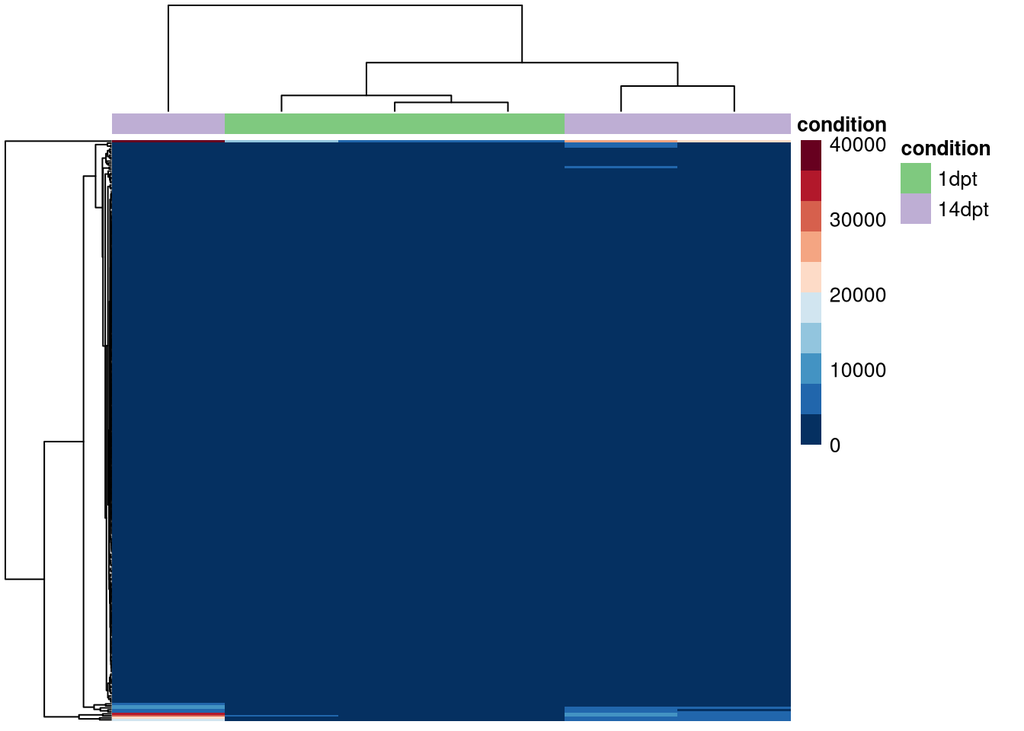

```r
pheatmap(heatmap_matrix_control,
         color = heatmap_colors,
         annotation_col = heatmap_annotation_control,
         annotation_colors = ann_colors,
         show_colnames = F,
         show_rownames = F)
```

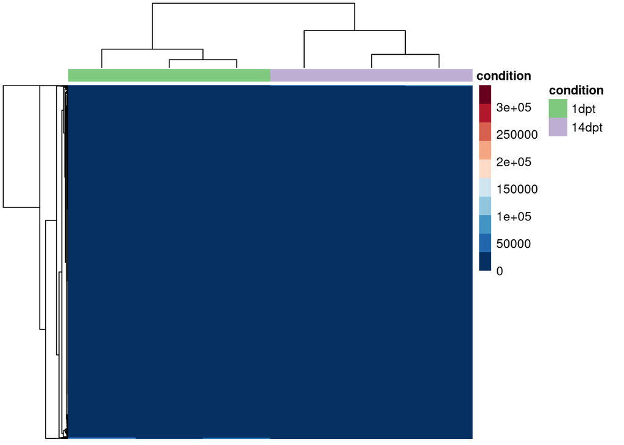

```r
pheatmap(heatmap_matrix_treatment,
         color = heatmap_colors,
         annotation_col = heatmap_annotation_treatment,
         annotation_colors = ann_colors,
         show_colnames = F,
         show_rownames = F)
```

The Z-score was then used to measure how different the samples were from the average expression levels

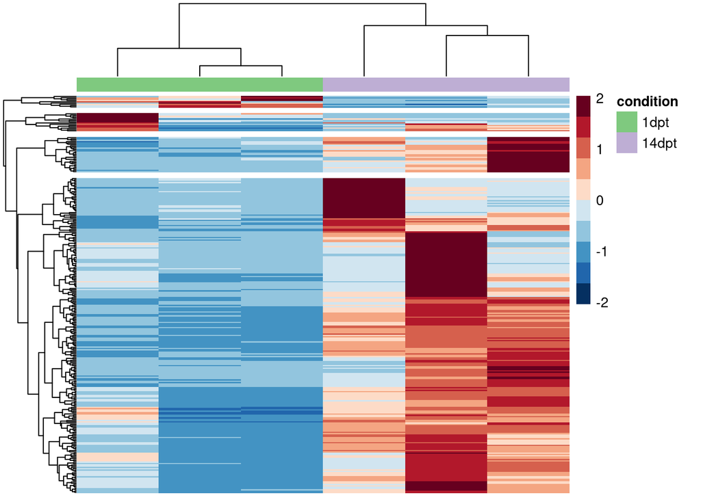

```r
#adding more variables and measuring expression by z-score (control)
heatmap_control <- pheatmap(heatmap_matrix_control,
                            color = heatmap_colors,
                            annotation_col = heatmap_annotation_control,
                            annotation_colors = ann_colors,
                            show_colnames = F,
                            show_rownames = F,
                            scale = "row",
                            annotation_names_col = F,
                            clustering_distance_cols = "euclidean",
                            clustering_method = "complete",
                            cutree_rows = 4)
```

Upregulated (red) = 15 Downregulated (blue) = 276

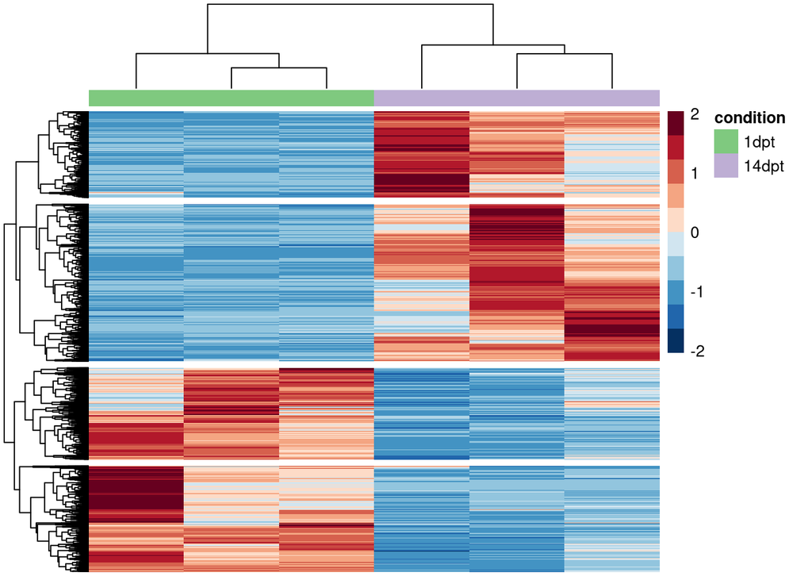

```r
heatmap_treatment <- pheatmap(heatmap_matrix_treatment,
                            color = heatmap_colors,
                            annotation_col = heatmap_annotation_treatment,
                            annotation_colors = ann_colors,
                            show_colnames = F,
                            show_rownames = F,
                            scale = "row",
                            annotation_names_col = F,
                            clustering_distance_cols = "euclidean",
                            clustering_method = "complete",
                            cutree_rows = 4)
```

Upregulated (red) = 2578 Downregulated (blue) = 3176

# Pathway Analysis

## Creating background Gene Set

```r
# generating lists of genes for GO analysis
resdata_control_background <- select(resdata_control,
                                Gene_id,
                                log2FoldChange,
                                padj)

resdata_treatment_background <- select(resdata_treatment,
                                Gene_id,
                                log2FoldChange,
                                padj)
```

```r
# isolating Log2FoldChange data
original_gene_list_control <- resdata_control_background$log2FoldChange
original_gene_list_treatment <- resdata_treatment_background$log2FoldChange

head(original_gene_list_control)
```

```
## [1] -3.888703 -4.113838 -7.223383 -4.393335 -6.751922 -3.871503
```

```r
head(original_gene_list_treatment)
```

```
## [1] -7.262966 -5.841158 -5.503397 -7.108026 -6.656960  6.055200
```

```r
# omit any NA values
background_gene_list_control<-na.omit(original_gene_list_control)
background_gene_list_treatment<-na.omit(original_gene_list_treatment)

# sort the gene lists in decreasing order (required for clusterProfiler)
background_gene_list_control = sort(background_gene_list_control, decreasing = TRUE)
background_gene_list_treatment = sort(background_gene_list_treatment, decreasing = TRUE)

# Name the vector
names(background_gene_list_control) <- resdata_control_background$Gene_id
names(background_gene_list_treatment) <- resdata_treatment_background$Gene_id

# making background gene lists into dataframes
background_gene_list_control <- as.data.frame(background_gene_list_control)
background_gene_list_treatment <- as.data.frame(background_gene_list_treatment)


head(background_gene_list_control)
```

```
##              background_gene_list_control
## Os01g0764050                     8.834912
## Os09g0522200                     7.724497
## Os12g0132500                     7.019621
## Os05g0135750                     6.860277
## Os11g0134950                     6.737365
## Os07g0147500                     5.734981
```

```r
head(background_gene_list_treatment)
```

```
##              background_gene_list_treatment
## Os02g0585700                      11.885764
## Os09g0522200                      11.130379
## Os12g0225150                      10.382884
## Os03g0158550                       9.422309
## Os09g0522000                       9.254048
## Os02g0568700                       8.721010
```

## Creating Significant Gene Set

Generating Significant Gene Set for Control Dataset

```r
# Extract significant results (padj < 0.05) using subset()
sig_genes_df = subset(resdata_control_background, padj < 0.05)

# From significant results, we want to filter on log2fold change
sig_genes_control <- sig_genes_df$log2FoldChange

# Name the vector
names(sig_genes_control) <- sig_genes_df$Gene_id

# omit NA values
sig_genes_control <- na.omit(sig_genes_control)

# filter on min log2fold change (log2FoldChange > 1)
sig_genes_control <- names(sig_genes_control)[abs(sig_genes_control) > 1]

head(sig_genes_control)
```

```
## [1] "Os01g0764050" "Os09g0522200" "Os12g0132500" "Os05g0135750" "Os11g0134950"
## [6] "Os07g0147500"
```

```r
# Extract significant results (padj < 0.05) using subset()
sig_genes_df = subset(resdata_treatment_background, padj < 0.05)

# From significant results, we want to filter on log2fold change
sig_genes_treatment <- sig_genes_df$log2FoldChange

# Name the vector
names(sig_genes_treatment) <- sig_genes_df$Gene_id

# omit NA values
sig_genes_treatment <- na.omit(sig_genes_treatment)

# filter on min log2fold change (log2FoldChange > 1)
sig_genes_treatment <- names(sig_genes_treatment)[abs(sig_genes_treatment) > 1]

head(sig_genes_treatment)
```

```
## [1] "Os02g0585700" "Os09g0522200" "Os12g0225150" "Os03g0158550" "Os09g0522000"
## [6] "Os02g0568700"
```

Note: Since I could not get clusterProfiler or any igraph dependent packages to load, I have the remaining code commented out. This is the analysis I would have performed if I were able to get these packages to install and libraries to load.

## GO Enrichment Analysis

This analysis helps to identify the pathways using gprofiler2.

```r
#GO_control <- gost(
#  query = sig_genes_control,
#  organism = "osativa",
#  correction_method = "fdr",
#  sources = c("GO:BP", "GO:MF", "GO:CC"),  # Gene Ontology categories
#  user_threshold = 0.05)

#head(GO_control)
```

```r
#GO_treatment <- gost(
#  query = sig_genes_treatment,
#  organism = "osativa",
#  correction_method = "fdr",
#  sources = c("GO:BP", "GO:MF", "GO:CC"),  # Gene Ontology categories
#  user_threshold = 0.05)

#head(GO_treatment)
```

### Biological Processes

Control Results

```r
# Input Enrichment output
#GO_control_results <- GO_control$result

# Filter for Biological Process only
#GO_control_results_BP <- GO_control_results[GO_control_results$source == "GO:BP", ]

# Select top 10 terms by adjusted p-value
#GO_control_results_BP <- GO_control_results_BP[order(GO_control_results_BP$p_value), ][1:10, ]

# Convert -log10(p-value) for plotting
#GO_control_results_BP$log10_pval <- -log10(GO_control_results_BP$p_value)

# Order terms for plotting
#GO_control_results_BP$term_name <- factor(GO_control_results_BP$term_name, levels = rev(GO_control_results_BP$term_name))
```

```r
# DOT PLOT
#ggplot(GO_control_results_BP, aes(x = log10_pval, y = term_name)) +
#  geom_point(aes(size = intersection_size), color = "blue") +
#  labs(title = "Dot Plot Top 10 GO Enriched Terms (Biological Process)",
#       x = "-log10(p-value)", y = "GO Term") +
#  theme_minimal()

# BAR PLOT
#ggplot(GO_control_results_BP, aes(x = log10_pval, y = term_name)) +
#  geom_col(fill = "steelblue") +
#  labs(title = "Bar Plot Top 10 GO Enriched Terms (Biological Process)",
#       x = "-log10(p-value)", y = "GO Term") +
#  theme_minimal()
```

Treatment Results

```r
# Input Enrichment output
#GO_treatment_results <- GO_treatment$result

# Filter for Biological Process only
#GO_treatment_results_BP <- GO_treatment_results[GO_treatmenr_results$source == "GO:BP", ]

# Select top 10 terms by adjusted p-value
#GO_treatment_results_BP <- GO_treatment_results_BP[order(GO_treatment_results_BP$p_value), ][1:10, ]

# Convert -log10(p-value) for plotting
#GO_treatment_results_BP$log10_pval <- -log10(GO_treatment_results_BP$p_value)

# Order terms for plotting
#GO_treatment_results_BP$term_name <- factor(GO_treatment_results_BP$term_name, levels = rev(GO_treatment_results_BP$term_name))
```

```r
# DOT PLOT
#ggplot(GO_treatment_results_BP, aes(x = log10_pval, y = term_name)) +
#  geom_point(aes(size = intersection_size), color = "orange") +
#  labs(title = "Dot Plot Top 10 GO Enriched Terms (Biological Process)",
#       x = "-log10(p-value)", y = "GO Term") +
#  theme_minimal()

# BAR PLOT
#ggplot(GO_treatment_results_BP, aes(x = log10_pval, y = term_name)) +
#  geom_col(fill = "coral") +
#  labs(title = "Bar Plot Top 10 GO Enriched Terms (Biological Process)",
#       x = "-log10(p-value)", y = "GO Term") +
#  theme_minimal()
```

### Cellular Function

Control Results

```r
# Filter for Cellular Function only
#GO_control_results_CF <- GO_control_results[GO_control_results$source == "GO:CF", ]

# Select top 10 terms by adjusted p-value
#GO_control_results_CF <- GO_control_results_CF[order(GO_control_results_CF$p_value), ][1:10, ]

# Convert -log10(p-value) for plotting
#GO_control_results_CF$log10_pval <- -log10(GO_control_results_CF$p_value)

# Order terms for plotting
#GO_control_results_CF$term_name <- factor(GO_control_results_CF$term_name, levels = rev(GO_control_results_CF$term_name))
```

```r
# DOT PLOT
#ggplot(GO_control_results_CF, aes(x = log10_pval, y = term_name)) +
#  geom_point(aes(size = intersection_size), color = "blue") +
#  labs(title = "Dot Plot Top 10 GO Enriched Terms (Cellular Function)",
#       x = "-log10(p-value)", y = "GO Term") +
#  theme_minimal()

# BAR PLOT
#ggplot(GO_control_results_CF, aes(x = log10_pval, y = term_name)) +
#  geom_col(fill = "steelblue") +
#  labs(title = "Bar Plot Top 10 GO Enriched Terms (Cellular Function)",
#       x = "-log10(p-value)", y = "GO Term") +
#  theme_minimal()
```

Treatment Results

```r
# Filter for Cellular Function only
#GO_treatment_results_CF <- GO_treatment_results[GO_treatment_results$source == "GO:CF", ]

# Select top 10 terms by adjusted p-value
#GO_treatment_results_CF <- GO_treatment_results_CF[order(GO_treatment_results_CF$p_value), ][1:10, ]

# Convert -log10(p-value) for plotting
#GO_treatment_results_CF$log10_pval <- -log10(GO_treatment_results_CF$p_value)

# Order terms for plotting
#GO_treatment_results_CF$term_name <- factor(GO_treatment_results_CF$term_name, levels = rev(GO_treatment_results_CF$term_name))
```

```r
# DOT PLOT
#ggplot(GO_treatment_results_CF, aes(x = log10_pval, y = term_name)) +
#  geom_point(aes(size = intersection_size), color = "orange") +
#  labs(title = "Dot Plot Top 10 GO Enriched Terms (Cellular Function)",
#       x = "-log10(p-value)", y = "GO Term") +
#  theme_minimal()

# BAR PLOT
#ggplot(GO_treatment_results_CF, aes(x = log10_pval, y = term_name)) +
#  geom_col(fill = "coral") +
#  labs(title = "Bar Plot Top 10 GO Enriched Terms (Cellular Function)",
#       x = "-log10(p-value)", y = "GO Term") +
#  theme_minimal()
```

### Molecular Function

Control Results

```r
# Filter for Molecular Function only
#GO_control_results_MF <- GO_control_results[GO_control_results$source == "GO:MF", ]

# Select top 10 terms by adjusted p-value
#GO_control_results_MF <- GO_control_results_MF[order(GO_control_results_MF$p_value), ][1:10, ]

# Convert -log10(p-value) for plotting
#GO_control_results_MF$log10_pval <- -log10(GO_control_results_MF$p_value)

# Order terms for plotting
#GO_control_results_MF$term_name <- factor(GO_control_results_MF$term_name, levels = rev(GO_control_results_MF$term_name))
```

```r
# DOT PLOT
#ggplot(GO_control_results_MF, aes(x = log10_pval, y = term_name)) +
#  geom_point(aes(size = intersection_size), color = "blue") +
#  labs(title = "Dot Plot Top 10 GO Enriched Terms (Molecular Function)",
#       x = "-log10(p-value)", y = "GO Term") +
#  theme_minimal()

# BAR PLOT
#ggplot(GO_control_results_MF, aes(x = log10_pval, y = term_name)) +
#  geom_col(fill = "steelblue") +
#  labs(title = "Bar Plot Top 10 GO Enriched Terms (Molecular Function)",
#       x = "-log10(p-value)", y = "GO Term") +
#  theme_minimal()
```

Treatment Results

```r
# Filter for Cellular Function only
#GO_treatment_results_MF <- GO_treatment_results[GO_treatment_results$source == "GO:MF", ]

# Select top 10 terms by adjusted p-value
#GO_treatment_results_MF <- GO_treatment_results_MF[order(GO_treatment_results_MF$p_value), ][1:10, ]

# Convert -log10(p-value) for plotting
#GO_treatment_results_MF$log10_pval <- -log10(GO_treatment_results_MF$p_value)

# Order terms for plotting
#GO_treatment_results_MF$term_name <- factor(GO_treatment_results_MF$term_name, levels = rev(GO_treatment_results_MF$term_name))
```

```r
# DOT PLOT
#ggplot(GO_treatment_results_MF, aes(x = log10_pval, y = term_name)) +
#  geom_point(aes(size = intersection_size), color = "orange") +
#  labs(title = "Dot Plot Top 10 GO Enriched Terms (Molecular Function)",
#       x = "-log10(p-value)", y = "GO Term") +
#  theme_minimal()

# BAR PLOT
#ggplot(GO_treatment_results_MF, aes(x = log10_pval, y = term_name)) +
#  geom_col(fill = "coral") +
#  labs(title = "Bar Plot Top 10 GO Enriched Terms (Molecular Function)",
#      x = "-log10(p-value)", y = "GO Term") +
#  theme_minimal()
```

# Figure Generation

Here I am just putting visualizations together to create figures similar to those in the publication.

## Figure 1

```r
figure_1 <- plot_grid(pca_control, pca_treatment, volcanoplot_control, volcanoplot_treatment,
                        labels = c("A", "B", "C", "D"),
                        ncol = 2, nrow = 2)
ggsave("figure_1.pdf", figure_1, width = 8, height = 8)
```

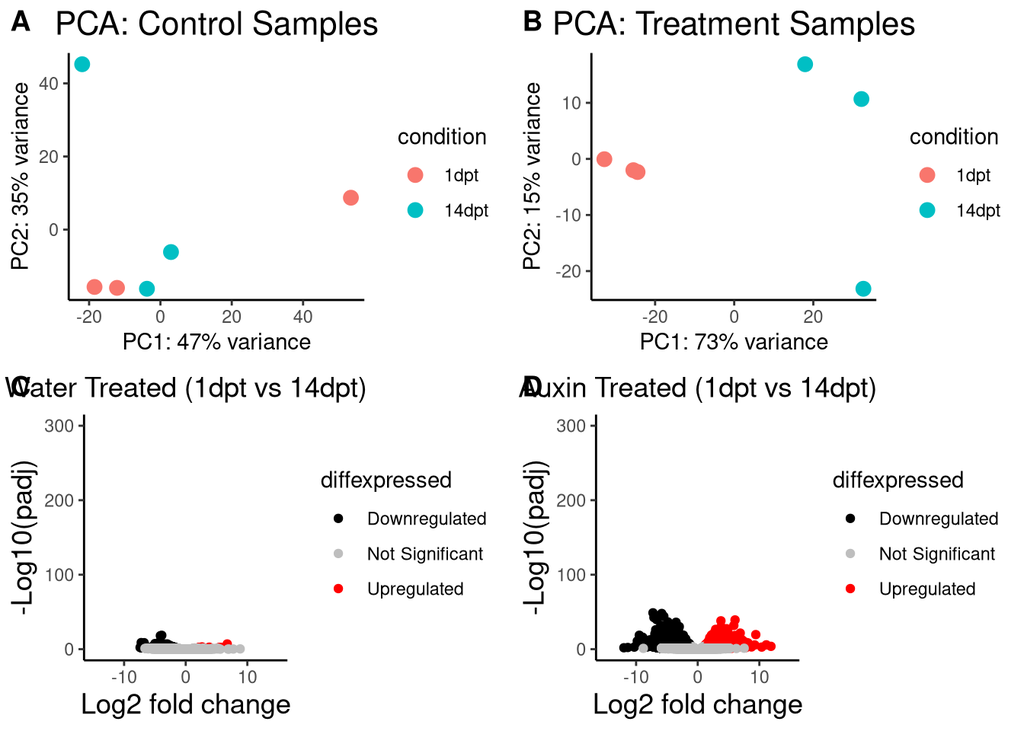

Figure 1: (A)PCA plot of control (water) samples, colored by condition. (B)PCA plot of treatment (auxin) samples, colored by condition. (C)Volcano plot of differentially expressed genes in control (water) samples, left = downregulated and right = upregulated. (D)Volcano plot of differentially expressed genes in treatment (auxin) samples, left = downregulated and right = upregulated.

```r
#Figure 1 with figure caption
print(figure_1)
```

## Figure 2

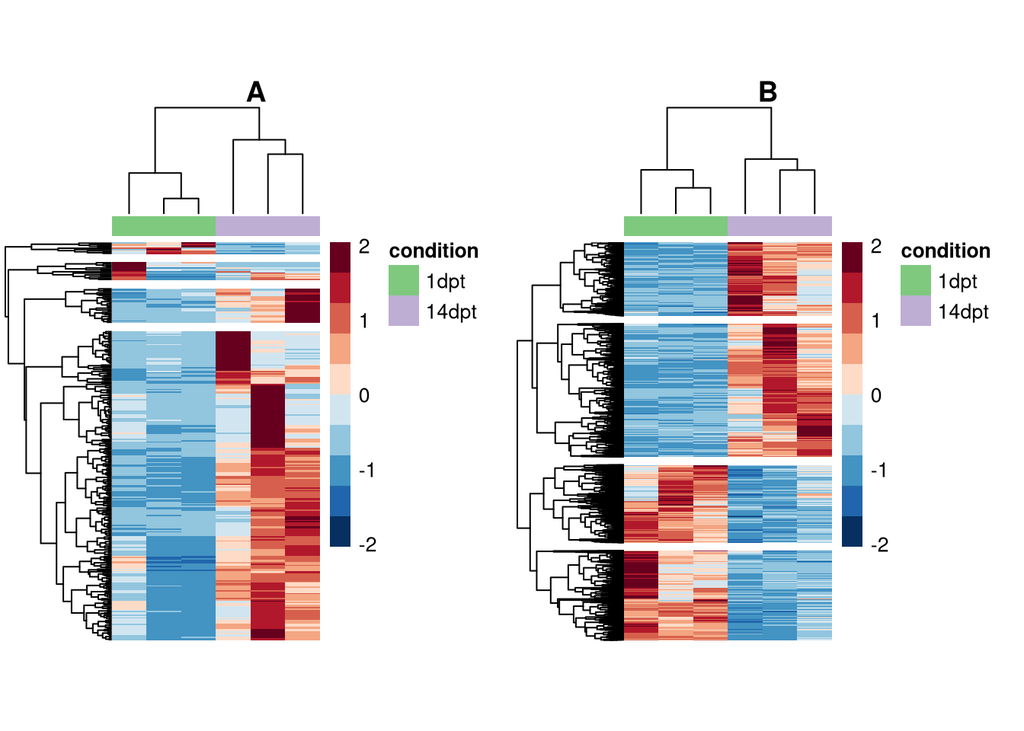

Figure 2: (A)Heatmap of differentially expressed genes for control samples.(B)Heatap of differentially expressed genes for treatment samples. For both heatmaps:expression is based off of a normalized z-score, red = high expression, white = average expression, blue = low expression

```r
label_A <- textGrob("A", gp = gpar(fontsize = 14, fontface = "bold"))
label_B <- textGrob("B", gp = gpar(fontsize = 14, fontface = "bold"))

figure_2 <- grid.arrange(
  label_A, label_B, heatmap_control$gtable, heatmap_treatment$gtable,
  ncol = 2,
  heights = unit.c(unit(0.75, "lines"), unit(0.75, "npc"))
)
```

```r
#making a pdf version
label_A <- textGrob("A", gp = gpar(fontsize = 14, fontface = "bold"))
label_B <- textGrob("B", gp = gpar(fontsize = 14, fontface = "bold"))

# Arrange heatmaps with labels using grid.arrange
pdf("figure_2.pdf", width = 10, height = 8)
grid.arrange(
  label_A, label_B, heatmap_control$gtable, heatmap_treatment$gtable,
  ncol = 2,
  heights = unit.c(unit(0.75, "lines"), unit(0.75, "npc"))
)
dev.off()
```